# Week 8 Case Study 01

## Exploratory Data Analysis

In this section we will perform an exploratory data analysis (EDA) of the `Beers` and `Breweries` datasets. These datasets can be found in the `datasets` directory for the project. The project will attempt to investigate the data by performing the following steps:

- Determine the number of breweries present in each state.
- Merge beer data with the breweries data. Print the first 6 observations and the last six observations to check the merged file.
- Address the missing values in each column.
- Compute the median alcohol content and international bitterness unit for each state. Plot a bar chart to compare.
- Identify the state with the maximum alcoholic (ABV) beer. Identify which state has the most bitter (IBU) beer.
- Comment on the summary statistics and distribution of the ABV variable.
- Identify any relationship between the bitterness of the beer and its alcoholic content. Draw a scatter plot. Make your best judgment of a relationship and EXPLAIN your answer.
- Investigate the difference with respect to IBU and ABV between IPAs (India Pale Ales) and other types of Ale (any beer with “Ale” in its name other than IPA). Use KNN classificationto investigate this relationship. Provide statistical evidence one way or the other.

### 1. Determine the number of breweries present in each state

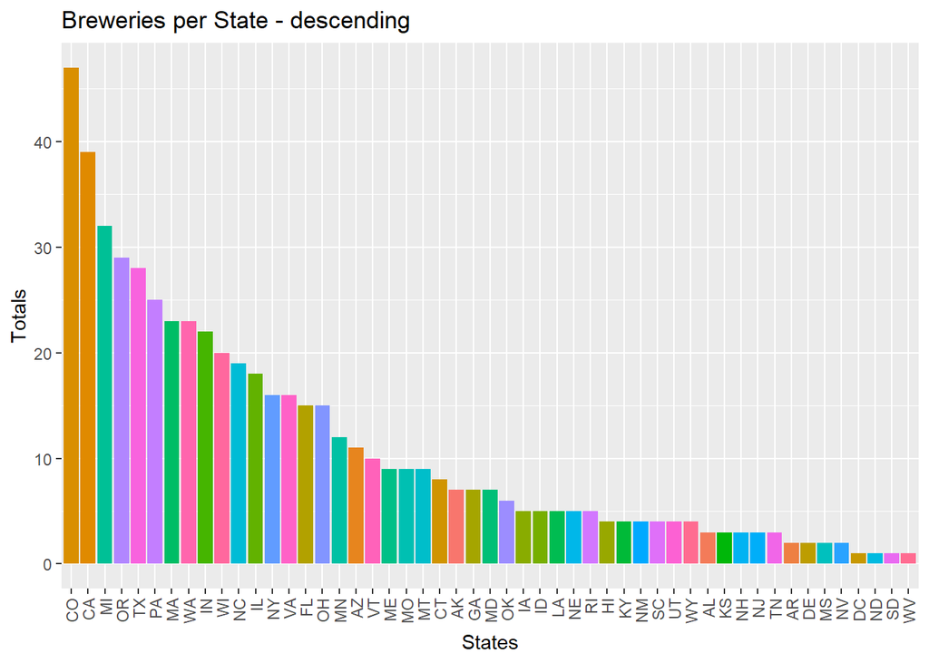

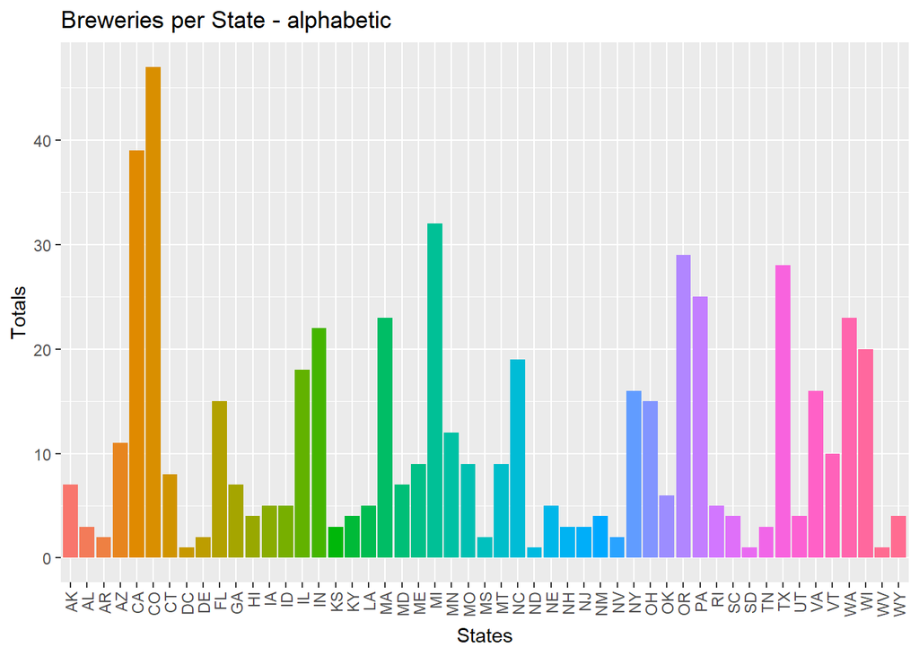

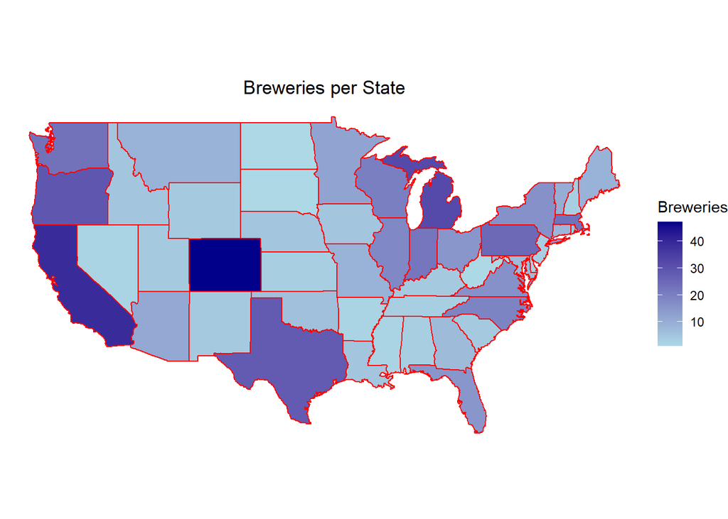

### 2. Merge beer data with the breweries data

We will merge the data from the two files into a single dataset. This dataset will be used for further analysis.

```
##   Brew_ID     Beer_Name Beer_ID   ABV IBU                               Style
## 1       1  Get Together    2692 0.045  50                        American IPA
## 2       1 Maggie's Leap    2691 0.049  26                  Milk / Sweet Stout
## 3       1    Wall's End    2690 0.048  19                   English Brown Ale
## 4       1       Pumpion    2689 0.060  38                         Pumpkin Ale
## 5       1    Stronghold    2688 0.060  25                     American Porter
## 6       1   Parapet ESB    2687 0.056  47 Extra Special / Strong Bitter (ESB)
##   Ounces          Brew_Name        City State
## 1     16 NorthGate Brewing  Minneapolis    MN
## 2     16 NorthGate Brewing  Minneapolis    MN
## 3     16 NorthGate Brewing  Minneapolis    MN
## 4     16 NorthGate Brewing  Minneapolis    MN
## 5     16 NorthGate Brewing  Minneapolis    MN
## 6     16 NorthGate Brewing  Minneapolis    MN
```

```
##      Brew_ID                 Beer_Name Beer_ID   ABV IBU
## 2405     556             Pilsner Ukiah      98 0.055  NA
## 2406     557  Heinnieweisse Weissebier      52 0.049  NA
## 2407     557           Snapperhead IPA      51 0.068  NA
## 2408     557         Moo Thunder Stout      50 0.049  NA
## 2409     557         Porkslap Pale Ale      49 0.043  NA
## 2410     558 Urban Wilderness Pale Ale      30 0.049  NA
##                        Style Ounces                     Brew_Name          City
## 2405         German Pilsener     12         Ukiah Brewing Company         Ukiah
## 2406              Hefeweizen     12       Butternuts Beer and Ale Garrattsville
## 2407            American IPA     12       Butternuts Beer and Ale Garrattsville
## 2408      Milk / Sweet Stout     12       Butternuts Beer and Ale Garrattsville
## 2409 American Pale Ale (APA)     12       Butternuts Beer and Ale Garrattsville
## 2410        English Pale Ale     12 Sleeping Lady Brewing Company     Anchorage
##      State
## 2405    CA
## 2406    NY
## 2407    NY
## 2408    NY
## 2409    NY
## 2410    AK
```

### 3. Address the missing values in each column

To address the missing values in each column we decided to try and keep the data and not use `na.omit`. To keep the rows with `NA` values we will replace `NA` with `0`. This will allow us to retain approximately 40% of the dataset for various uses.

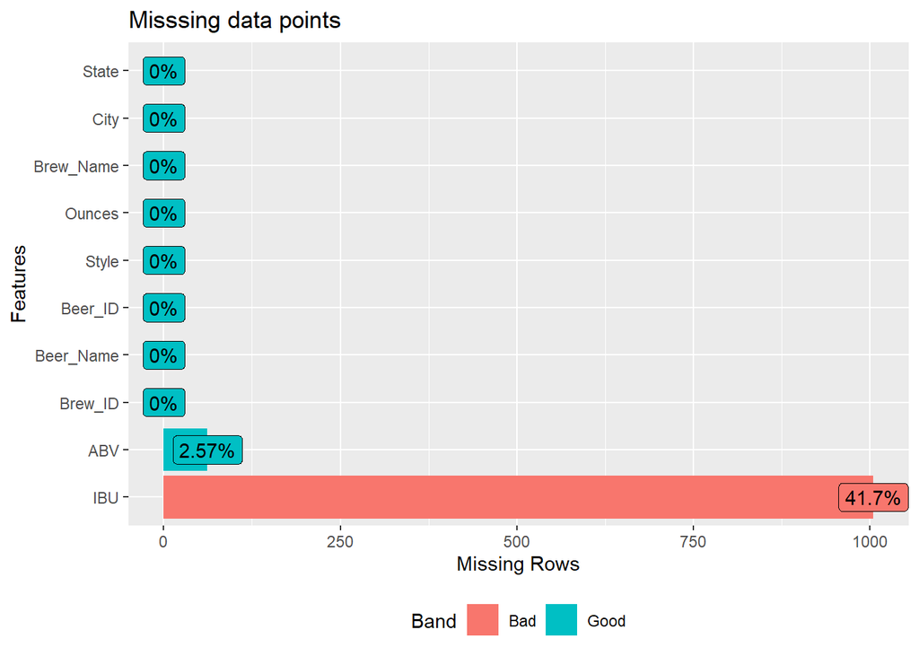

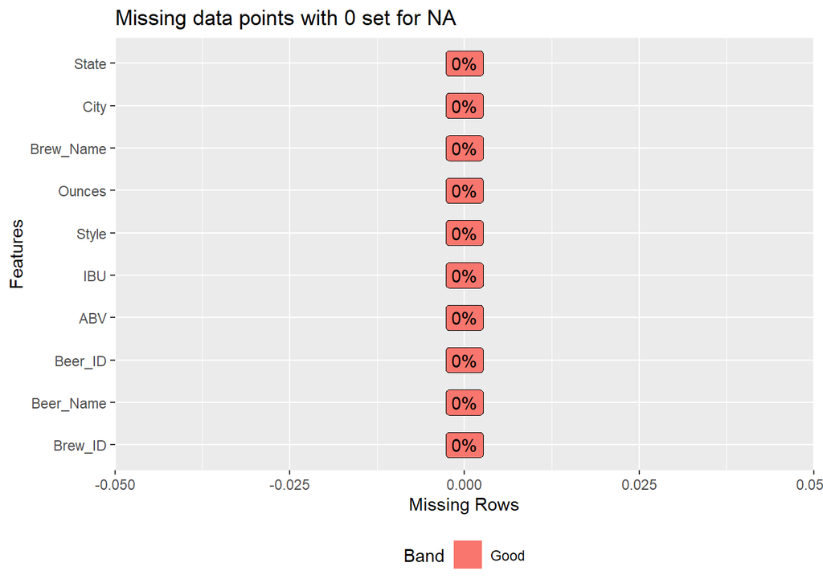

This is farily straight forward. However, we need to be sure to replace all `0` values with `NA` and drop them prior to graphing. Also, we will scale the `y` axis and rotate the labels on the `x` axis so that things are a little more readable.

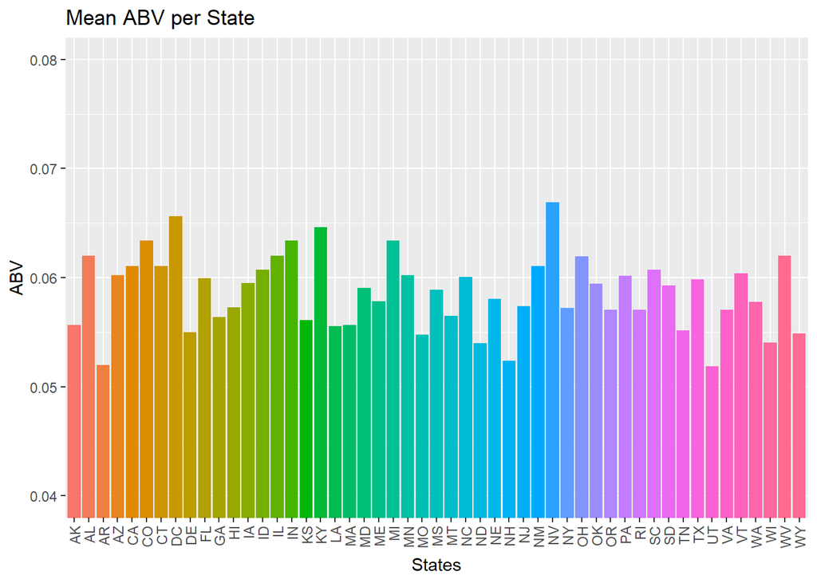

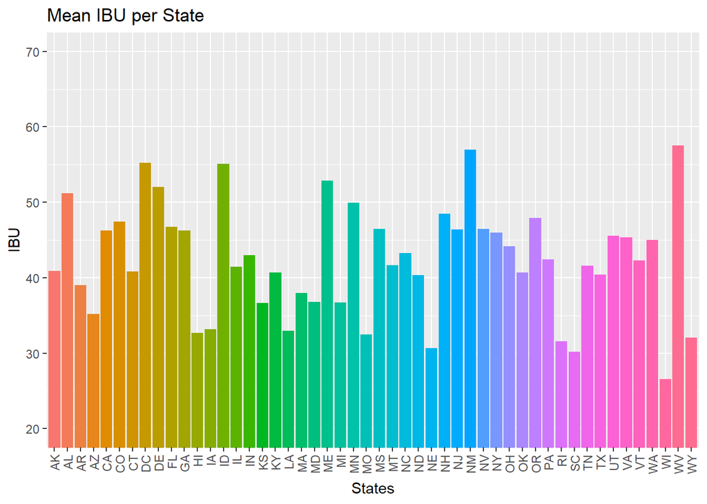

### 5. Identify the state with the maximum ABV and the state with the maximum IBU

The state with the maximum ABV value is CO with a value of 0.128. The state with the maximum IBU value is OR with a value of 138.

### 6. Comment on the summary statistics and distribution of the ABV variable.

To generate the summary statistics of the ABV variable we remove all rows with `0` and use the `Summary` function. This function lists the 5 number summary. To graphically inspect the data we generate a boxplot of the ABV variable. Additionally, we used a histogram graph to show the distribution of the ABV data. When the histogram is combined with a standard normal distribution we can see the slight right-skew in the data.

```
##     State                ABV
##  Length:2348        Min.   :0.00100
##  Class :character   1st Qu.:0.05000
##  Mode  :character   Median :0.05600
##                     Mean   :0.05977
##                     3rd Qu.:0.06700
##                     Max.   :0.12800
```

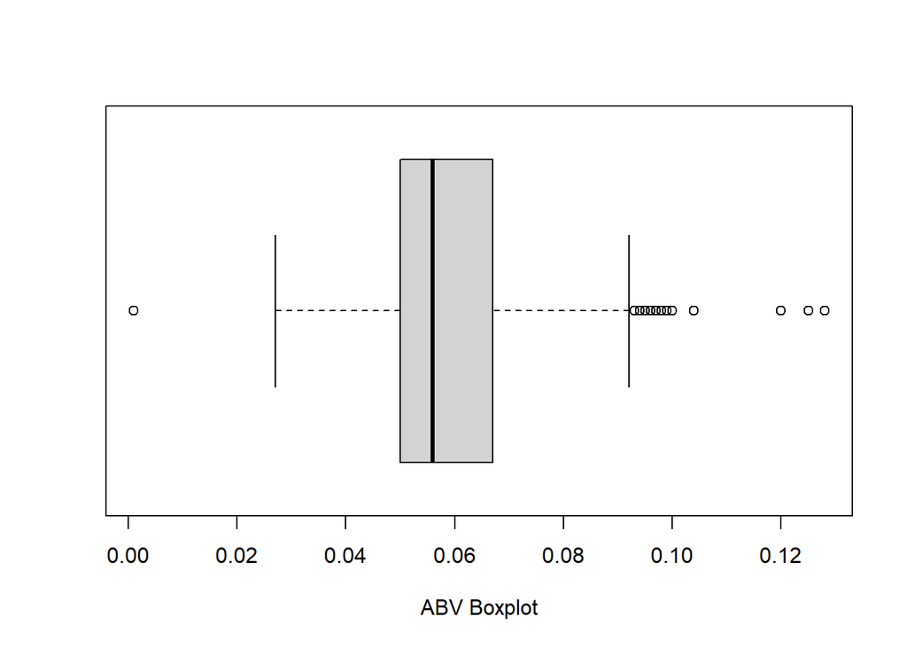

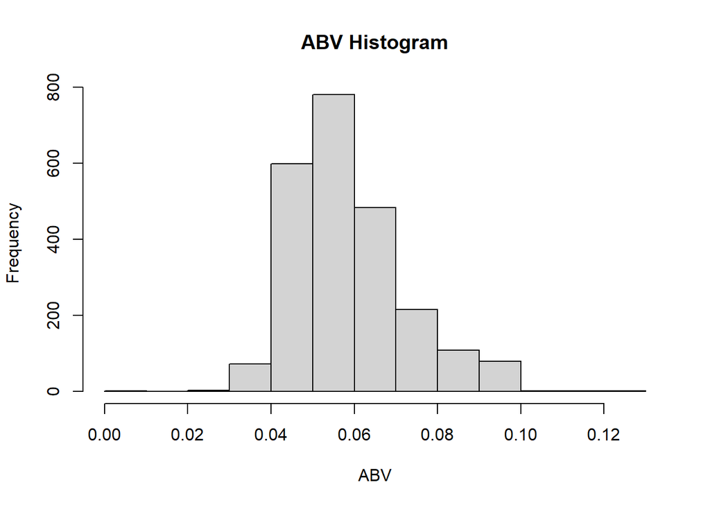

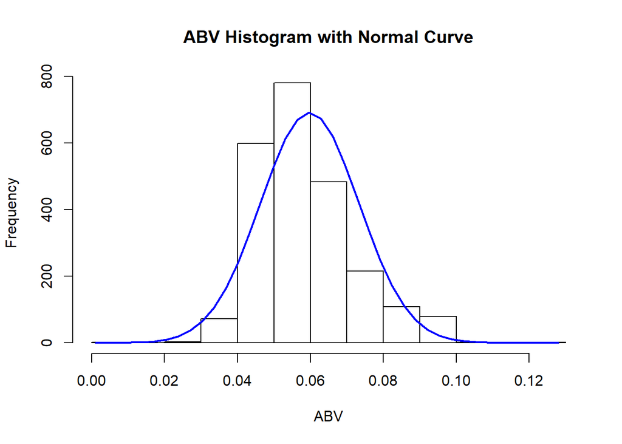

```
## integer(0)
```

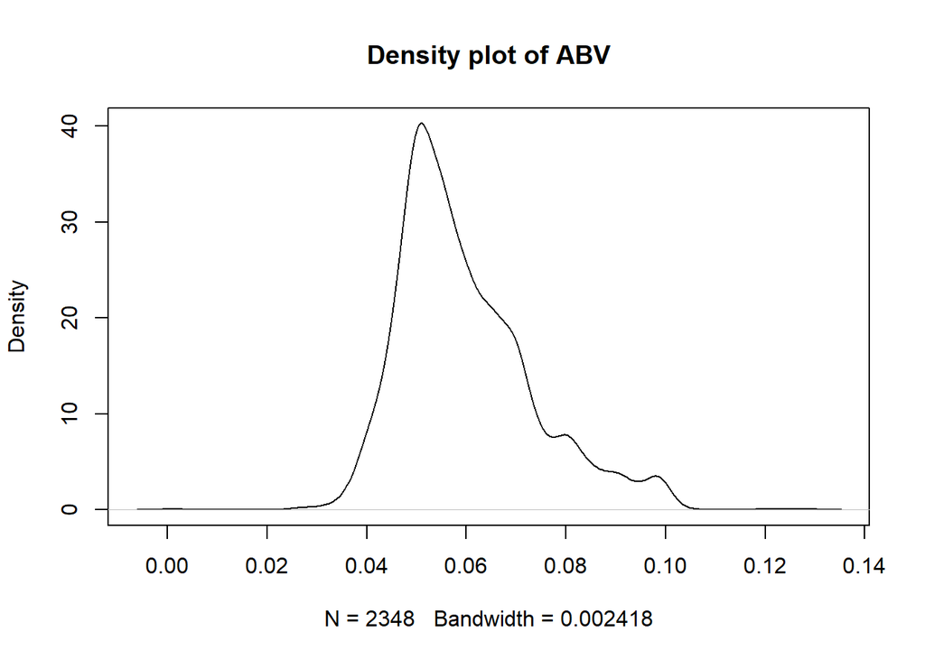

### 7. Identify any relationship between the bitterness of the beer and its alcoholic content. Draw a scatter plot. Make your best judgment of a relationship and EXPLAIN your answer.

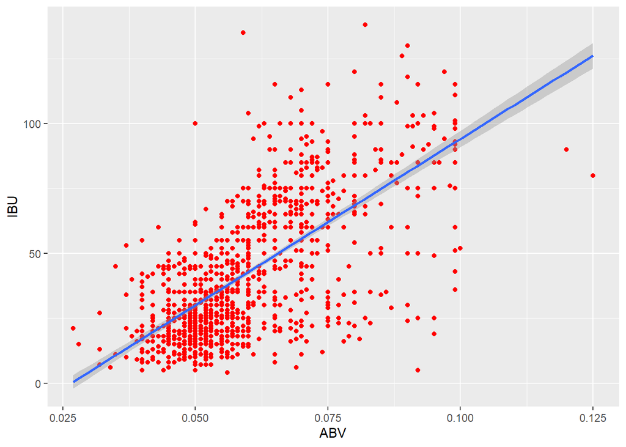

```
##           ABV       IBU
## ABV 1.0000000 0.6706215
## IBU 0.6706215 1.0000000
```

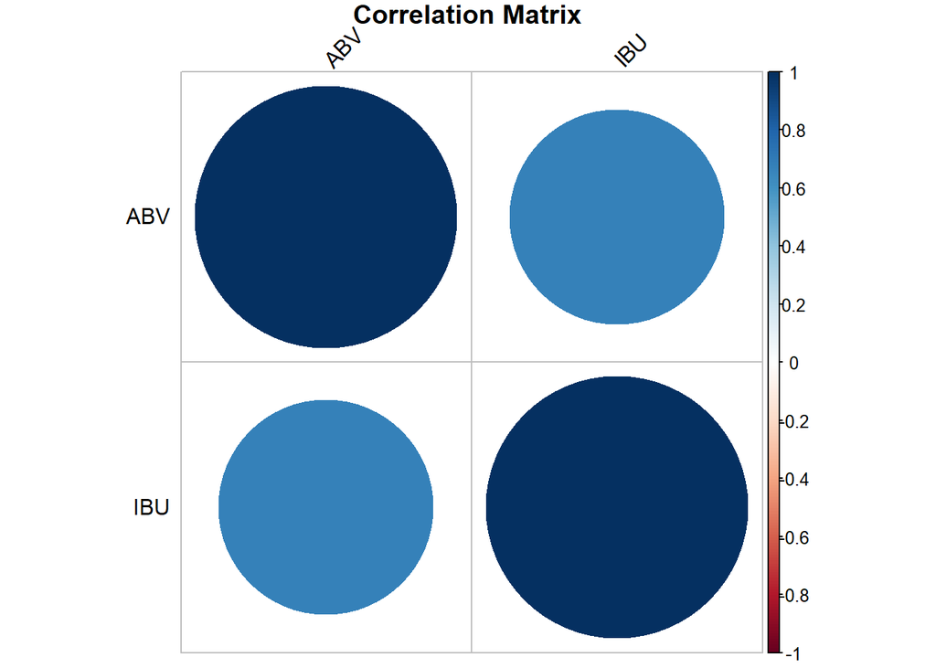

### 8 Investigate the difference with respect to IBU and ABV between IPAs and other types of Ale

Use KNN classification to investigate this relationship. Provide statistical evidence one way or the other.

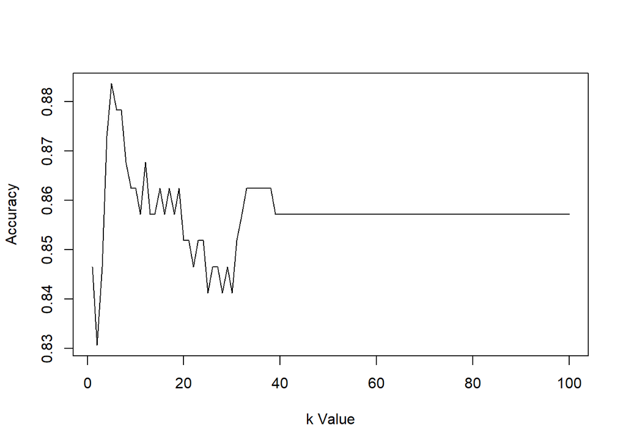

```
## Confusion Matrix and Statistics
##
##
## knnipa Ale IPA
##    Ale  92  15
##    IPA   7  75
##
##                Accuracy : 0.8836
##                  95% CI : (0.8291, 0.9256)
##     No Information Rate : 0.5238
##     P-Value [Acc > NIR] : <2e-16
##
##                   Kappa : 0.7657
##
##  Mcnemar's Test P-Value : 0.1356
##
##             Sensitivity : 0.9293
##             Specificity : 0.8333
##          Pos Pred Value : 0.8598
##          Neg Pred Value : 0.9146
##              Prevalence : 0.5238
##          Detection Rate : 0.4868
##    Detection Prevalence : 0.5661
##       Balanced Accuracy : 0.8813
##
##        'Positive' Class : Ale
##
```

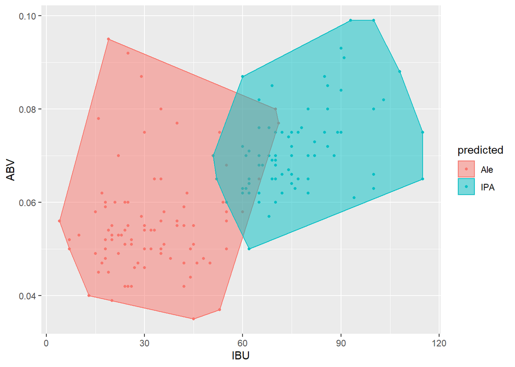

### 9. Knock their socks off! Find one other useful inference from the data that you feel

Budweiser may be able to find value in. You must convince them why it is important and back up your conviction with appropriate statistical evidence.

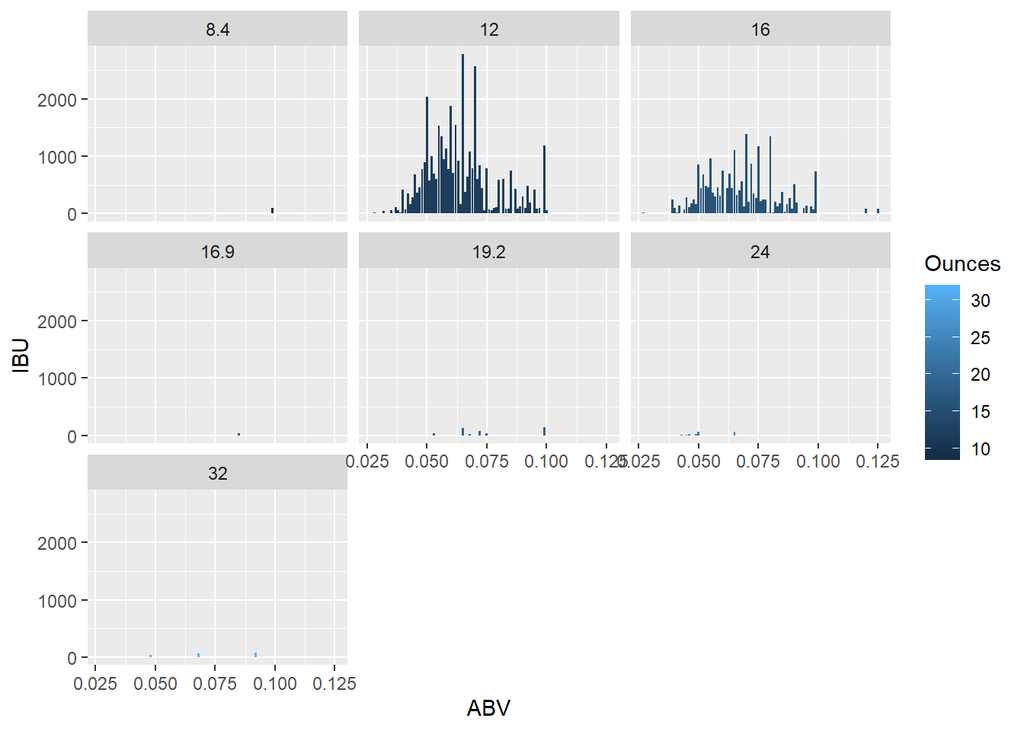

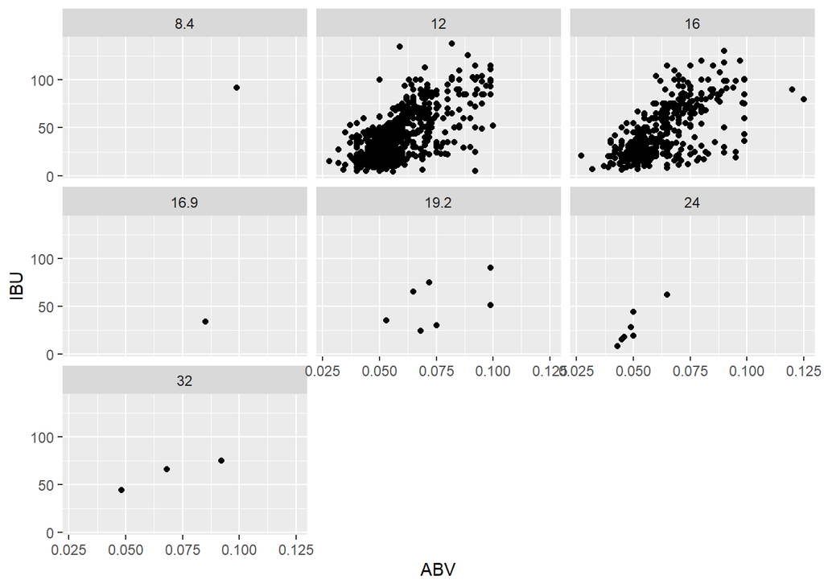

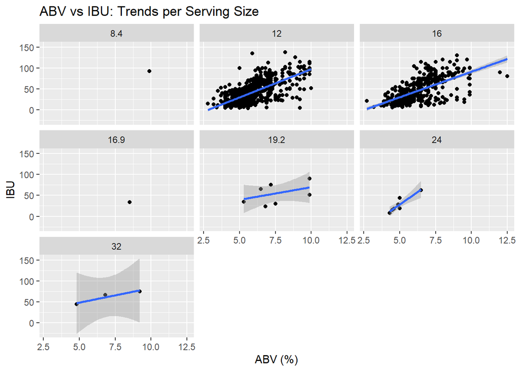

```
## # A tibble: 8 x 2
##   `factor(Type)` no_rows
##   <fct>            <int>
## 1 ALE                976
## 2 CIDER               37
## 3 HEF                 40
## 4 IPA                558
## 5 LAGER              158
## 6 PILS                27
## 7 PORT                74
## 8 STOUT              100
```

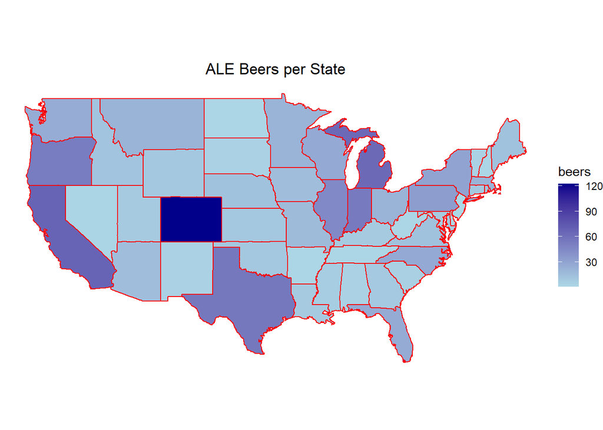

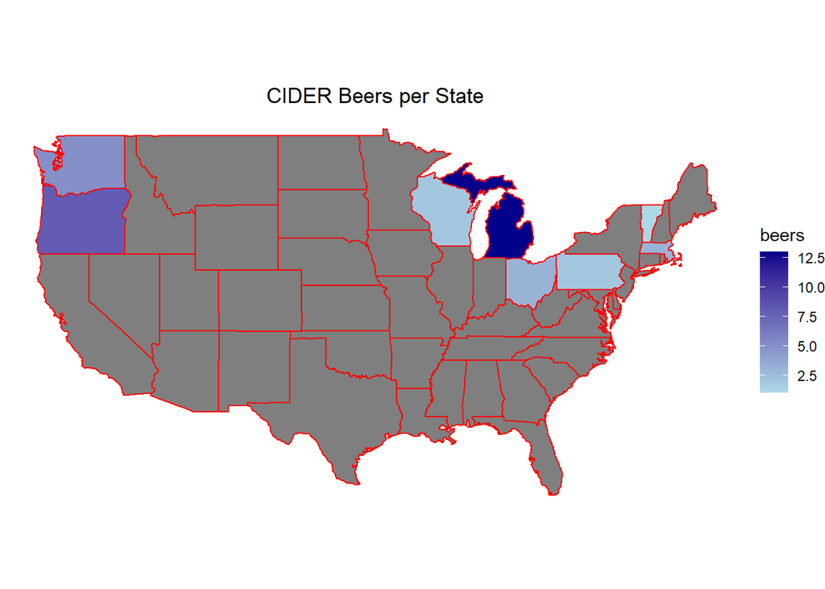

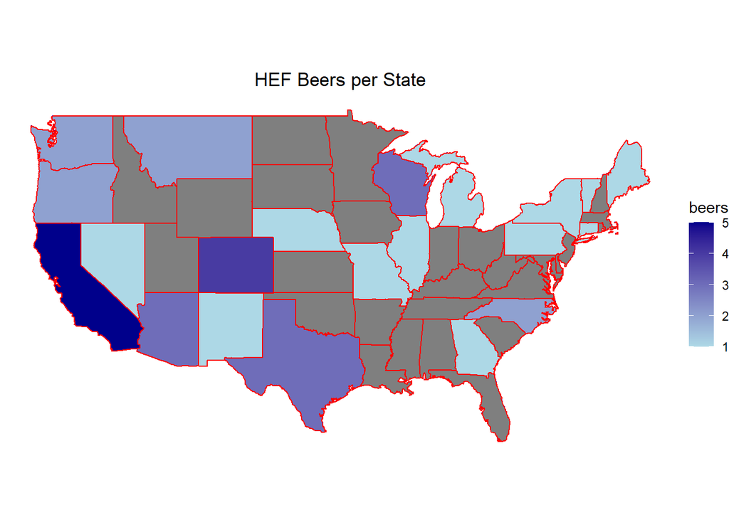

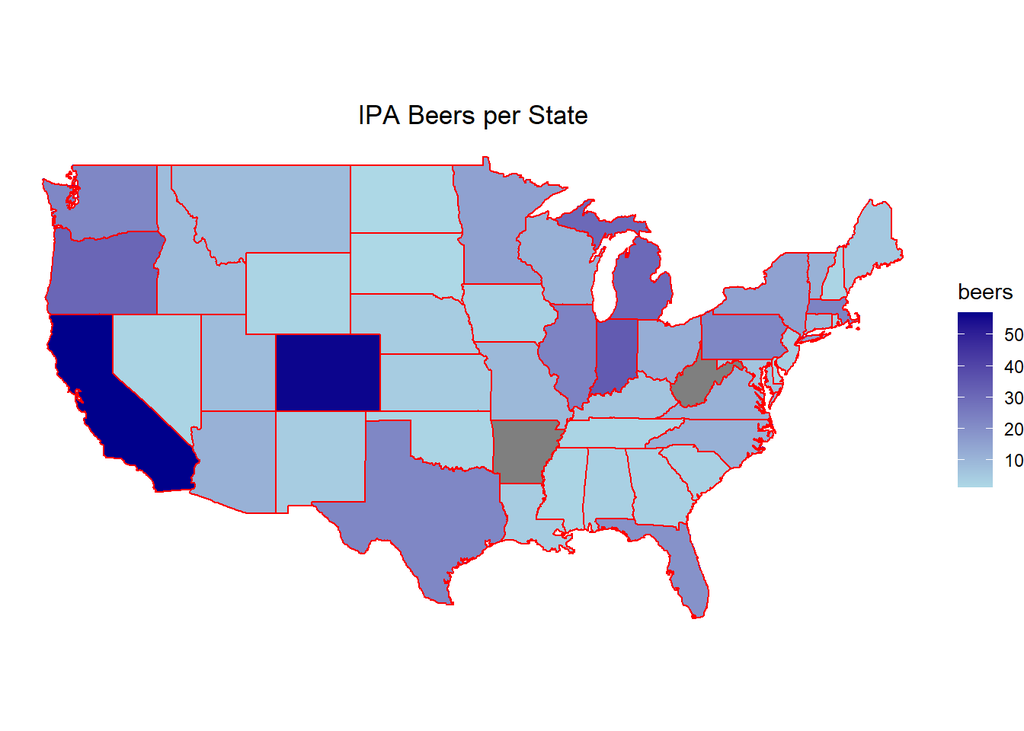

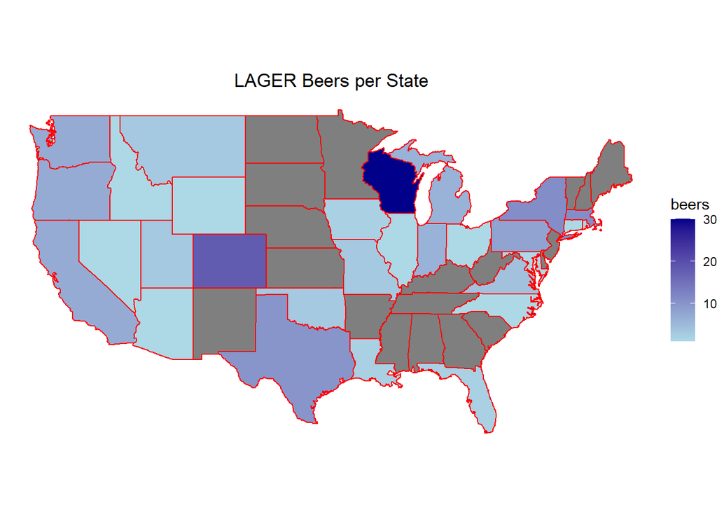

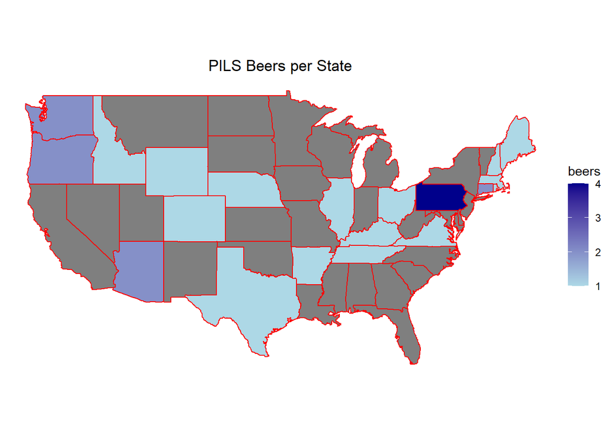

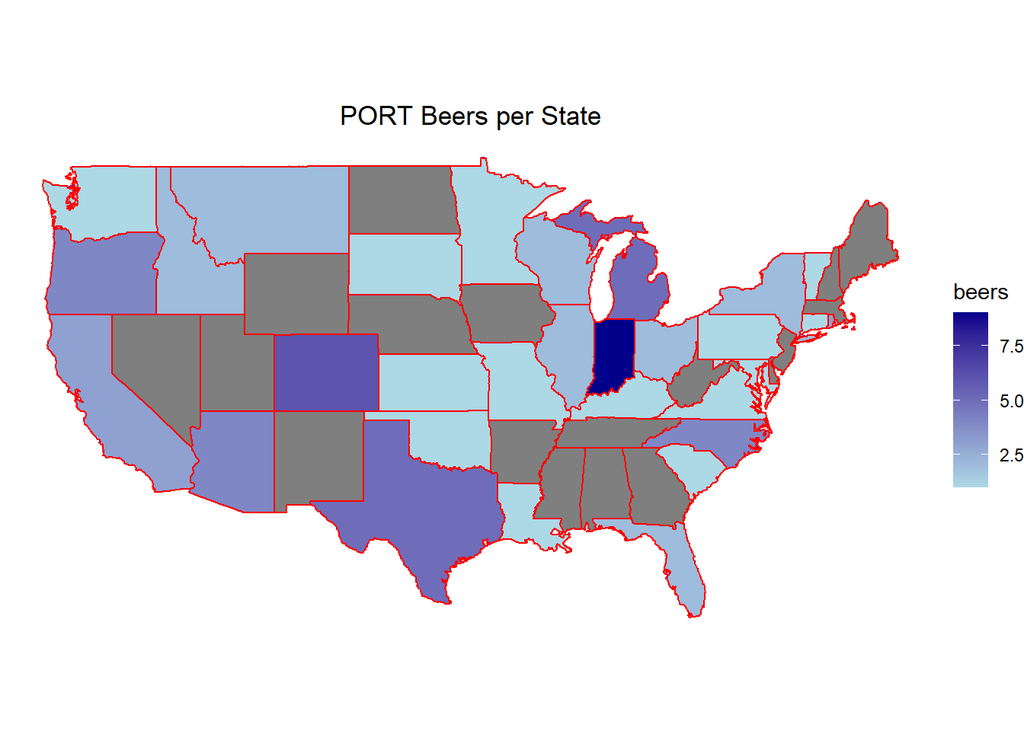

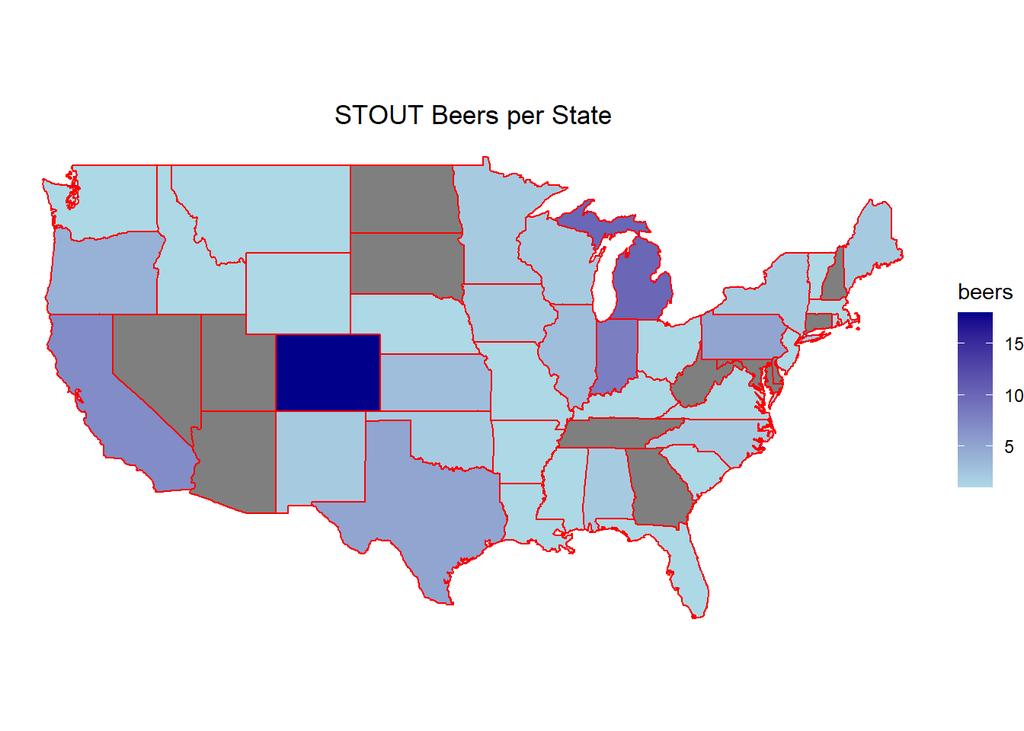